# Explorative Analyses

Claudio Zanettini

2020-07-27 23:08:14

Data summary

| Name | dat_clean |
| --- | --- |
| Number of rows | 1288 |
| Number of columns | 32 |
| _______________________ |  |
| Column type frequency: |  |
| Date | 2 |
| factor | 14 |
| numeric | 16 |
| ________________________ |  |
| Group variables | None |

**Variable type: Date**

| skim_variable | n_missing | complete_rate | min | max | median | n_unique |
| --- | --- | --- | --- | --- | --- | --- |
| data_visita | 0 | 1 | 2017-01-11 | 2019-12-30 | 2018-07-16 | 545 |
| ddn | 0 | 1 | 2002-08-05 | 2019-11-12 | 2017-10-11 | 905 |

**Variable type: factor**

| skim_variable | n_missing | complete_rate | ordered | n_unique | top_counts |
| --- | --- | --- | --- | --- | --- |
| luogo_visita | 12 | 0.99 | FALSE | 2 | ost: 789, aon: 487 |
| sesso | 0 | 1.00 | FALSE | 2 | m: 745, f: 543 |
| gemellarita | 0 | 1.00 | FALSE | 2 | no: 1158, si: 130 |
| inviati | 35 | 0.97 | FALSE | 5 | pas: 392, ped: 261, int: 240, alt: 203 |
| tipo_fecondazione | 27 | 0.98 | FALSE | 2 | nat: 1102, ass: 159 |
| situazione_presenatione | 43 | 0.97 | FALSE | 3 | cef: 1090, pod: 93, alt: 62 |
| tipo_parto_amb | 23 | 0.98 | FALSE | 5 | vag: 534, ces: 328, ces: 242, vag: 154 |
| tipo_parto | 23 | 0.98 | FALSE | 3 | ces: 577, vag: 534, vag: 154 |
| allattamento | 89 | 0.93 | FALSE | 3 | sen: 563, art: 403, mis: 233 |
| mdc_1 | 0 | 1.00 | FALSE | 31 | dis: 548, vis: 181, ref: 107, tor: 67 |
| mdc_2 | 759 | 0.41 | FALSE | 29 | ref: 84, dis: 72, col: 70, tor: 64 |
| mdc_3 | 1118 | 0.13 | FALSE | 24 | col: 26, alt: 20, dac: 20, ref: 18 |
| mdc_4 | 1257 | 0.02 | FALSE | 12 | col: 7, dac: 5, alt: 4, dif: 3 |
| mdc_full | 0 | 1.00 | FALSE | 31 | dis: 548, vis: 181, ref: 107, tor: 67 |

**Variable type: numeric**

| skim_variable | n_missing | complete_rate | mean | sd | p0 | p25 | p50 | p75 | p100 | hist |
| --- | --- | --- | --- | --- | --- | --- | --- | --- | --- | --- |
| anno_visita | 0 | 1.00 | 2018.05 | 0.80 | 2017 | 2017 | 2018 | 2019.00 | 2019.0 | ▇▁▇▁▇ |
| fascia_eta_gestazionale | 0 | 1.00 | 3.82 | 0.55 | 1 | 4 | 4 | 4.00 | 5.0 | ▁▁▁▇▁ |
| fascia_eta_visita | 0 | 1.00 | 1.33 | 0.68 | 1 | 1 | 1 | 1.00 | 4.0 | ▇▂▁▁▁ |
| eta_madre_parto | 42 | 0.97 | 35.05 | 4.79 | 18 | 32 | 35 | 38.00 | 53.0 | ▁▅▇▂▁ |
| n_gravidanze | 28 | 0.98 | 1.35 | 0.56 | 1 | 1 | 1 | 2.00 | 6.0 | ▇▁▁▁▁ |
| CC | 428 | 0.67 | 33.85 | 2.02 | 24 | 33 | 34 | 35.00 | 38.8 | ▁▁▂▇▂ |
| peso | 226 | 0.82 | 3023.20 | 637.44 | 750 | 2750 | 3110 | 3449.50 | 4620.0 | ▁▂▆▇▁ |
| lunghezza | 262 | 0.80 | 49.01 | 3.25 | 34 | 48 | 50 | 51.00 | 56.0 | ▁▁▂▇▂ |
| apgar_1 | 239 | 0.81 | 8.56 | 1.13 | 0 | 9 | 9 | 9.00 | 11.0 | ▁▁▁▂▇ |
| apgar_5 | 244 | 0.81 | 9.60 | 0.79 | 3 | 9 | 10 | 10.00 | 11.0 | ▁▁▁▃▇ |
| codice_mdc_1 | 0 | 1.00 | 5.85 | 7.29 | 1 | 1 | 2 | 7.00 | 32.0 | ▇▁▁▁▁ |
| codice_mdc_2 | 759 | 0.41 | 9.61 | 8.78 | 1 | 2 | 5 | 16.00 | 30.0 | ▇▂▁▂▂ |
| codice_mdc_3 | 1118 | 0.13 | 13.54 | 9.40 | 1 | 3 | 14 | 20.75 | 31.0 | ▇▂▃▆▂ |
| codice_mdc_4 | 1257 | 0.02 | 15.10 | 9.59 | 1 | 3 | 16 | 25.00 | 28.0 | ▇▁▅▃▇ |
| n_trattamenti | 5 | 1.00 | 3.65 | 3.43 | 1 | 1 | 2 | 5.00 | 31.0 | ▇▁▁▁▁ |
| eta_paziente | 0 | 1.00 | 17.34 | 32.76 | 1 | 2 | 4 | 11.00 | 194.0 | ▇▁▁▁▁ |

# Descrizione Variabili

# Soggetti

Nel corso di 3 anni (2017-2019), il nostro studio ha registrato informazioni riguardanti il trattamento osteopatico di 1288 pazienti, di cui il 58% (745) di sesso maschile. L’età dei soggetti é compresa tra un 1 mese e i 16 anni, con il 76% (979) dei pazienti di età non superiore all’anno di vita (fig.1).

Il tipo di parto più frequente è quello cesareo, 46% (577), seguito da quello vaginale e quello vaginale operativo, 42% (534) e 12% (154), rispettivamente (fig.2). Il 13% (159) dei soggetti è nato a sequito di fecondazione assistita e il 10% (130) in parto di tipo gemellare.

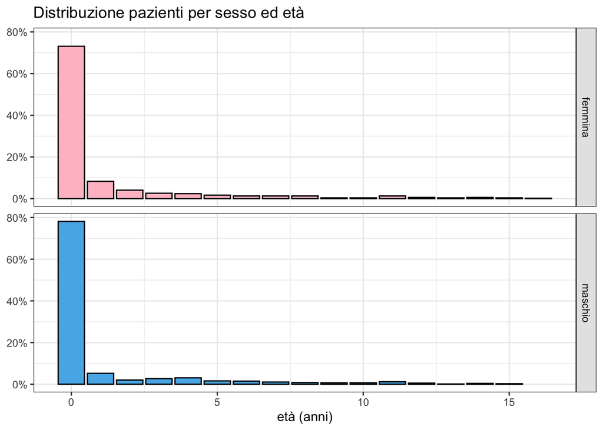

**Forse questo vale la pena cambiarlo ad un annno*

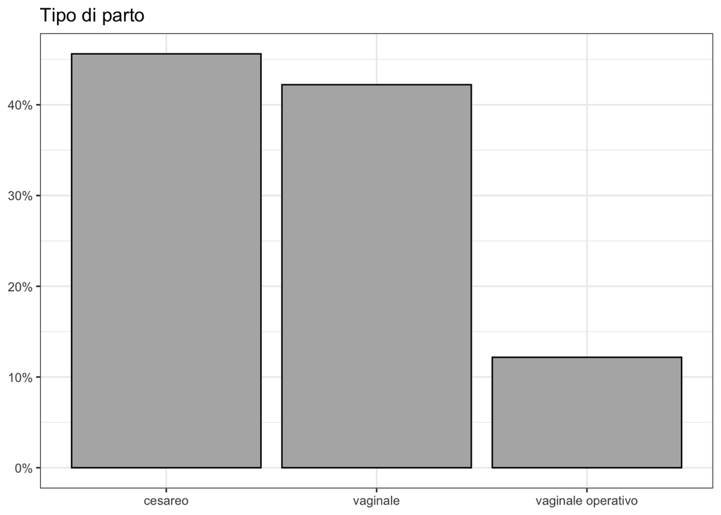

# Motivi di consulto

Un anno o meno

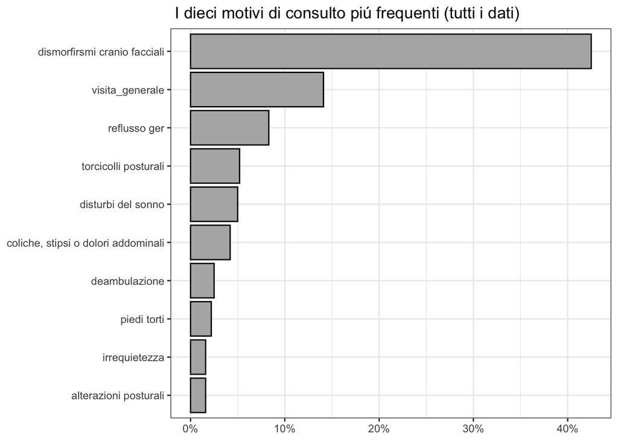

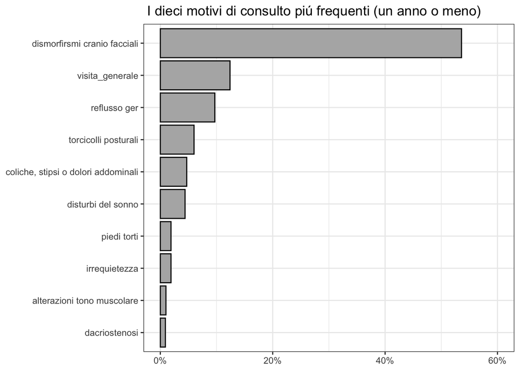

# Un anno o meno

Se vogliamo vedere qualcosa conviene fermarci ad un anno.

Visita generale e’ piu’ sano di uno che viene per trattamento specifico? Allora ti aspetti che faccia meno visite…

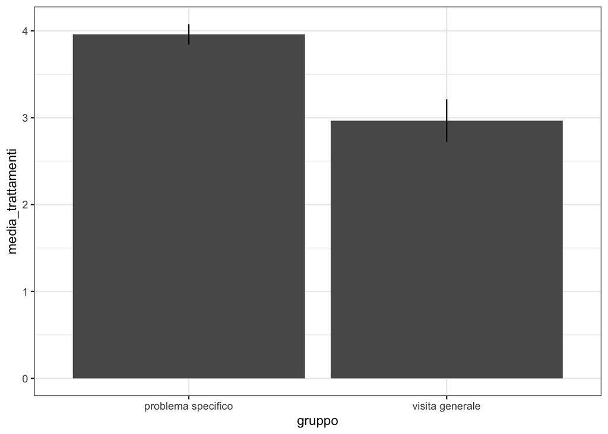

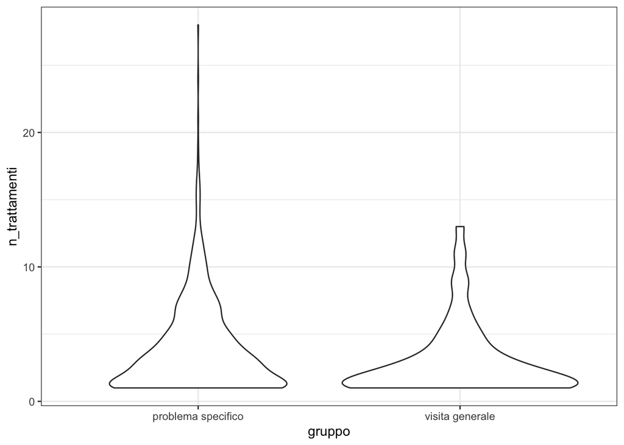

**Si in generale chi viene per un propblema specifico fa mediamente una visita in piu**

Se e’ vero che le percone con parto cesareo hanno in generale piu’ problemi, ed e’ per quello che vengono piu’ spesso, allora dovrebbero esserci piu’ soggetti con parto cesareo che non vengono per una visita generale.

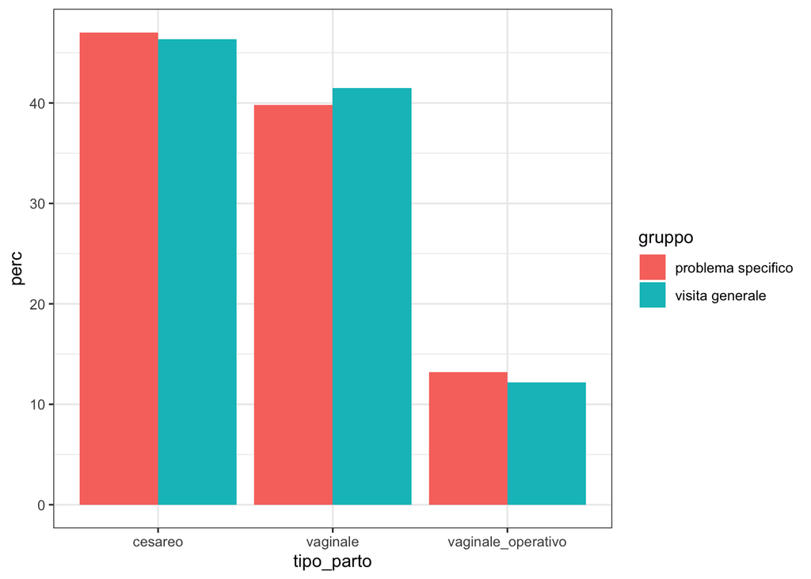

Si piu per visite specifiche, ma forse la misura non e’ sensibile abbastanza.

Quelli che vengono da un parto cesareo hanno mediamente piu visite? Piu o meno, si potrebbe regge.

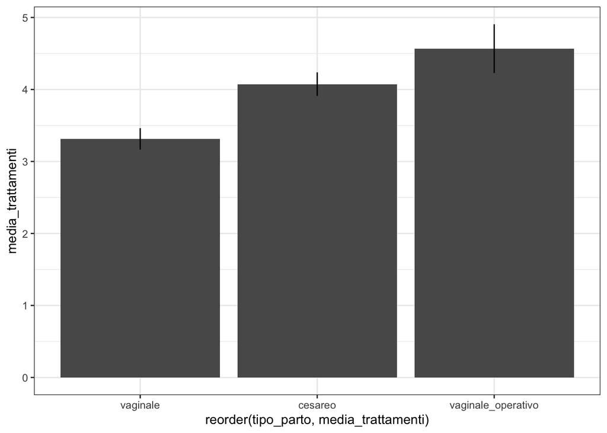